# US Brewery and Beer Case Study

Dan Crouthamel, Pradeep Pradeepkumar

June 24, 2019

## Case Study Introduction

Our client, Beer City, in Pennsylvania, is looking to expand their offering of domestic beer products. Using a recent list of 558 breweries and 2410 different beer products, we will assess some current interesting attributes about this landscape. This includes.

- Number of Breweries per State
- Median Alcohol Content per State (ABV)
- International Bitterness Unit per State (IBU)
- States with the highest ABV and IBU
- Statistical summary on ABV and the relationship between ABV and IBU
- Fun examination of highest ABV with low IBU

### Breweries per State

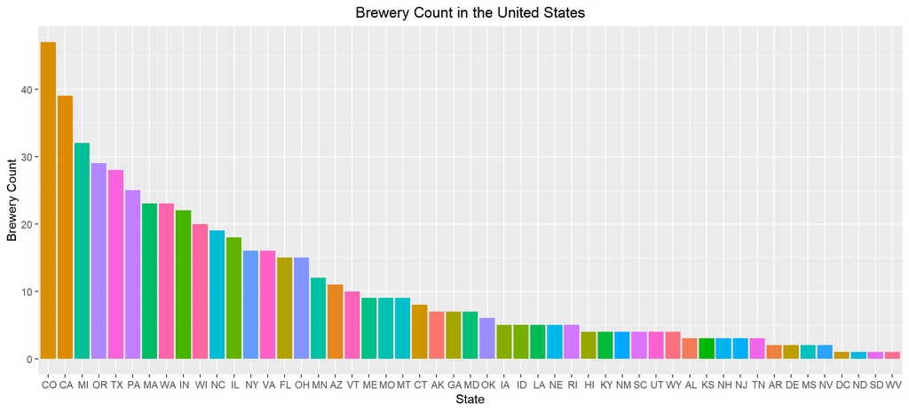

```r
brewData <- read.csv("Breweries.csv", header = TRUE)

# brewSummary <- summary(brewData$State)
# brewSummary

brewTable <- brewData %>% count(State)
names(brewTable) <- c("State","Count")
# brewTable

brewPlot <-ggplot(data=brewTable, aes(x=reorder(State, -Count), y=Count, fill=State))
brewPlot +
  geom_bar(stat="identity") +
  ylab("Brewery Count") +
  xlab("State") +
  ggtitle("Brewery Count in the United States") +
  theme(plot.title = element_text(hjust = 0.5), legend.position = "none")
```

The above graphic outlines the number of breweries in each state, with Colorado and California having the most.

### Read Beer data, then merge with Brewery data

```r
# Read beer data, then merge with Brewery data
beerData <- read.csv("Beers.csv")

# Clean up some columns so that things look nice when joining the tables
brewData %<>% rename("Brewery Name" = "Name")
beerData %<>% rename("Beer Name" = "Name")
beerData %<>% rename("Brew_ID" = "Brewery_id")

# Using inner_join of dplyr, could have used merged too, but I like this better
mergedData <- inner_join(brewData, beerData, by = c("Brew_ID" = "Brew_ID"))
kable(head(mergedData))
```

| Brew_ID | Brewery Name | City | State | Beer Name | Beer_ID | ABV | IBU | Style | Ounces |
| --- | --- | --- | --- | --- | --- | --- | --- | --- | --- |
| 1 | NorthGate Brewing | Minneapolis | MN | Get Together | 2692 | 0.045 | 50 | American IPA | 16 |
| 1 | NorthGate Brewing | Minneapolis | MN | Maggie’s Leap | 2691 | 0.049 | 26 | Milk / Sweet Stout | 16 |
| 1 | NorthGate Brewing | Minneapolis | MN | Wall’s End | 2690 | 0.048 | 19 | English Brown Ale | 16 |
| 1 | NorthGate Brewing | Minneapolis | MN | Pumpion | 2689 | 0.060 | 38 | Pumpkin Ale | 16 |
| 1 | NorthGate Brewing | Minneapolis | MN | Stronghold | 2688 | 0.060 | 25 | American Porter | 16 |
| 1 | NorthGate Brewing | Minneapolis | MN | Parapet ESB | 2687 | 0.056 | 47 | Extra Special / Strong Bitter (ESB) | 16 |

```r
kable(tail(mergedData))
```

|  | Brew_ID | Brewery Name | City | State | Beer Name | Beer_ID | ABV | IBU | Style | Ounces |
| --- | --- | --- | --- | --- | --- | --- | --- | --- | --- | --- |
| 2405 | 556 | Ukiah Brewing Company | Ukiah | CA | Pilsner Ukiah | 98 | 0.055 | NA | German Pilsener | 12 |
| 2406 | 557 | Butternuts Beer and Ale | Garrattsville | NY | Heinnieweisse Weissebier | 52 | 0.049 | NA | Hefeweizen | 12 |
| 2407 | 557 | Butternuts Beer and Ale | Garrattsville | NY | Snapperhead IPA | 51 | 0.068 | NA | American IPA | 12 |
| 2408 | 557 | Butternuts Beer and Ale | Garrattsville | NY | Moo Thunder Stout | 50 | 0.049 | NA | Milk / Sweet Stout | 12 |
| 2409 | 557 | Butternuts Beer and Ale | Garrattsville | NY | Porkslap Pale Ale | 49 | 0.043 | NA | American Pale Ale (APA) | 12 |
| 2410 | 558 | Sleeping Lady Brewing Company | Anchorage | AK | Urban Wilderness Pale Ale | 30 | 0.049 | NA | English Pale Ale | 12 |

A sample of the beginning and ending of the data set appears above and includes the following observations.

- Brew_ID
- Brewery Name
- City
- State
- Beer Name
- Beer_ID
- ABV
- IBU
- Style
- Ounces

### Report the number of NA’s in each column

```r
kable(colSums(is.na(mergedData)))
```

|  | x |
| --- | --- |
| Brew_ID | 0 |
| Brewery Name | 0 |
| City | 0 |
| State | 0 |
| Beer Name | 0 |
| Beer_ID | 0 |
| ABV | 62 |
| IBU | 1005 |
| Style | 0 |
| Ounces | 0 |

The above graphic shows us that we have 62 NAs in the ABV column, and 1005 NAs in the IBU column.

[figure not shown]

```r
# Medians
medianABV <- mergedData %>% group_by(State) %>% summarise(median = median(ABV, na.rm = TRUE))
medianIBU <- mergedData %>% group_by(State) %>% summarise(median = median(IBU, na.rm = TRUE))

medianABV <- mergedData %>% group_by(State) %>% summarise(median = mean(ABV, na.rm = TRUE))
medianIBU <- mergedData %>% group_by(State) %>% summarise(median = mean(IBU, na.rm = TRUE))

abvPlot <-ggplot(data=medianABV, aes(x=reorder(State,-median), y=median, fill=State))
abvPlot +
  geom_bar(stat="identity") +
  ylab("Median ABV") +
  xlab("State") +
  ggtitle("Median ABV (Alcohol By Volume) per State") +
  theme(plot.title = element_text(hjust = 0.5), legend.position = "top")
```

[figure not shown]

```r
ibuPlot <-ggplot(data=medianIBU, aes(x=reorder(State, -median), y=median, fill=State))
ibuPlot +
  geom_bar(stat="identity") +
  ylab("Median IBU") +
  xlab("State") +
  ggtitle("Median IBU (International Bitterness Units) per State") +
  theme(plot.title = element_text(hjust = 0.5), legend.position = "top")
```

There is no IBU data for South Dakota.

### Which state has the maximum alcoholic (ABV) beer? Which state has the most bitter (IBU) beer?

```r
# Max Stuff
maxABV <- mergedData %>% group_by(State) %>% summarise(max = max(ABV, na.rm = TRUE))
maxABV.row <- maxABV[which.max(maxABV$max),]
maxABV.row
```

```
## # A tibble: 1 x 2
##   State   max
##   <fct> <dbl>
## 1 " CO" 0.128
```

```r
maxIBU <- mergedData %>% group_by(State) %>% summarise(max = max(IBU, na.rm = TRUE))
maxIBU.row <- maxIBU[which.max(maxIBU$max),]
maxIBU.row
```

```
## # A tibble: 1 x 2
##   State   max
##   <fct> <dbl>
## 1 " OR"   138
```

Colorado has the highest ABV and Oregon has the highest IBU

### Summary statistics for the ABV variable.

```r
summary(mergedData$ABV)
```

```
##    Min. 1st Qu.  Median    Mean 3rd Qu.    Max.    NA's
## 0.00100 0.05000 0.05600 0.05977 0.06700 0.12800      62
```

```r
#summary(mergedData$ABV[!is.na(mergedData$ABV)])
```

There are 62 cases with no ABV data, which could be non-alcoholic beer. Maybe. The lowest is .001, which is considered non alcoholic and the highest is 12.8%, which is quite high for a beer. 50% of the data lies between 5 and 6.7 % ABV, which seems typical of beer.

### Is there an apparent relationship between the bitterness of the beer and its alcoholic content? Draw a scatter plot.

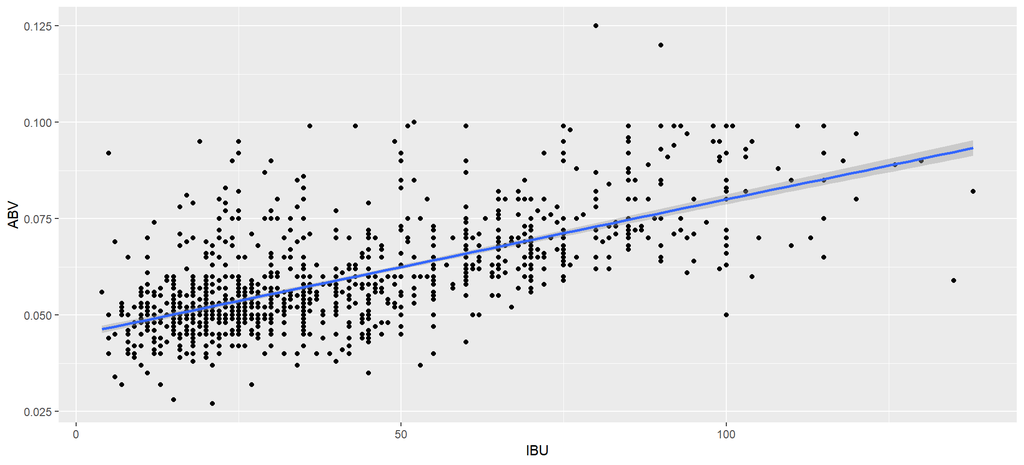

```r
mergedData1 <- na.omit(mergedData)
ggplot(mergedData1[!(is.na(mergedData1$IBU)|is.na(mergedData1$ABV)),], aes(x=IBU, y=ABV)) +
  geom_point() +
  geom_smooth(method = "lm", se = TRUE)
```

```r
summary(lm(mergedData1$ABV ~ mergedData1$IBU))
```

```
##
## Call:
## lm(formula = mergedData1$ABV ~ mergedData1$IBU)
##
## Residuals:
##       Min        1Q    Median        3Q       Max
## -0.033288 -0.005946 -0.001595  0.004022  0.052006
##
## Coefficients:
##                  Estimate Std. Error t value Pr(>|t|)
## (Intercept)     4.493e-02  5.177e-04   86.79   <2e-16 ***
## mergedData1$IBU 3.508e-04  1.036e-05   33.86   <2e-16 ***
## ---
## Signif. codes:  0 '***' 0.001 '**' 0.01 '*' 0.05 '.' 0.1 ' ' 1
##
## Residual standard error: 0.01007 on 1403 degrees of freedom
## Multiple R-squared:  0.4497, Adjusted R-squared:  0.4493
## F-statistic:  1147 on 1 and 1403 DF,  p-value: < 2.2e-16
```

Above we can see somewhat a linear trend between ABV and IBU. Something the should be considered though is the concept of relative bitterness vs perceived bitterness. For example, a beer that has 60 IBUs and is 6% ABV will taste about as bitter as a 90 IBU beer with 9% ABV. A higher ABV may indicate more malts, which is sweeter and will balance the precevied bitterness. So although there appears to be a weak linear trend, the average perceived bitterness could be flat (constant).

### Find a beer with maximum ABV and IBU less than 50

```r
ibu_nona <- mergedData[!is.na(mergedData$IBU),]
ibu_less_50 <- ibu_nona[ibu_nona$IBU < 50,]
max_abv <- head(ibu_less_50[order(ibu_less_50$ABV, decreasing = TRUE),],1)
name <- max_abv$`Beer Name`
```

Beer named Bourbon Barrel Batch 666: Sympathy for the Devil has highest alcohol content at 0.099 and IBV value at 36